# EasyVisa Project

## Context:

Business communities in the United States are facing high demand for human resources, but one of the constant challenges is identifying and attracting the right talent, which is perhaps the most important element in remaining competitive. Companies in the United States look for hard-working, talented, and qualified individuals both locally as well as abroad.

The Immigration and Nationality Act (INA) of the US permits foreign workers to come to the United States to work on either a temporary or permanent basis. The act also protects US workers against adverse impacts on their wages or working conditions by ensuring US employers' compliance with statutory requirements when they hire foreign workers to fill workforce shortages. The immigration programs are administered by the Office of Foreign Labor Certification (OFLC).

OFLC processes job certification applications for employers seeking to bring foreign workers into the United States and grants certifications in those cases where employers can demonstrate that there are not sufficient US workers available to perform the work at wages that meet or exceed the wage paid for the occupation in the area of intended employment.

## Objective:

In FY 2016, the OFLC processed 775,979 employer applications for 1,699,957 positions for temporary and permanent labor certifications. This was a nine percent increase in the overall number of processed applications from the previous year. The process of reviewing every case is becoming a tedious task as the number of applicants is increasing every year.

The increasing number of applicants every year calls for a Machine Learning based solution that can help in shortlisting the candidates having higher chances of VISA approval. OFLC has hired your firm EasyVisa for data-driven solutions. You as a data scientist have to analyze the data provided and, with the help of a classification model:

- Facilitate the process of visa approvals.
- Recommend a suitable profile for the applicants for whom the visa should be certified or denied based on the drivers that significantly influence the case status.

## Data Description

The data contains the different attributes of the employee and the employer. The detailed data dictionary is given below.

- case_id: ID of each visa application
- continent: Information of continent the employee
- education_of_employee: Information of education of the employee
- has_job_experience: Does the employee has any job experience? Y= Yes; N = No
- requires_job_training: Does the employee require any job training? Y = Yes; N = No
- no_of_employees: Number of employees in the employer's company
- yr_of_estab: Year in which the employer's company was established
- region_of_employment: Information of foreign worker's intended region of employment in the US.
- prevailing_wage: Average wage paid to similarly employed workers in a specific occupation in the area of intended employment. The purpose of the prevailing wage is to ensure that the foreign worker is not underpaid compared to other workers offering the same or similar service in the same area of employment.
- unit_of_wage: Unit of prevailing wage. Values include Hourly, Weekly, Monthly, and Yearly.
- full_time_position: Is the position of work full-time? Y = Full Time Position; N = Part Time Position
- case_status: Flag indicating if the Visa was certified or denied

## Importing necessary libraries and data

```python
import numpy as np
import pandas as pd
import matplotlib.pyplot as plt
import seaborn as sns
from sklearn.tree import DecisionTreeClassifier
from sklearn.model_selection import train_test_split
from sklearn.metrics import confusion_matrix, classification_report
from sklearn.metrics import accuracy_score,precision_score,recall_score,f1_score
import scipy.stats as stats
from sklearn import metrics
from sklearn import tree
from sklearn.model_selection import GridSearchCV
from sklearn.ensemble import BaggingClassifier
from sklearn.ensemble import RandomForestClassifier
from sklearn.metrics import roc_auc_score
from sklearn.linear_model import LogisticRegression
from sklearn.model_selection import train_test_split
from sklearn.model_selection import GridSearchCV
from sklearn import metrics
from sklearn.tree import DecisionTreeClassifier
from sklearn.ensemble import AdaBoostClassifier, GradientBoostingClassifier
from xgboost import XGBClassifier
import warnings
warnings.filterwarnings('ignore')
```

```python
df = pd.read_csv("EasyVisa.csv")
```

```python
df.head()
```

|  | case_id | continent | education_of_employee | has_job_experience | requires_job_training | no_of_employees | yr_of_estab | region_of_employment | prevailing_wage | unit_of_wage | full_time_position | case_status |
| --- | --- | --- | --- | --- | --- | --- | --- | --- | --- | --- | --- | --- |
| 0 | EZYV01 | Asia | High School | N | N | 14513 | 2007 | West | 592.2029 | Hour | Y | Denied |
| 1 | EZYV02 | Asia | Master's | Y | N | 2412 | 2002 | Northeast | 83425.6500 | Year | Y | Certified |
| 2 | EZYV03 | Asia | Bachelor's | N | Y | 44444 | 2008 | West | 122996.8600 | Year | Y | Denied |
| 3 | EZYV04 | Asia | Bachelor's | N | N | 98 | 1897 | West | 83434.0300 | Year | Y | Denied |
| 4 | EZYV05 | Africa | Master's | Y | N | 1082 | 2005 | South | 149907.3900 | Year | Y | Certified |

```python
df.info()
```

```
<class 'pandas.core.frame.DataFrame'>
RangeIndex: 25480 entries, 0 to 25479
Data columns (total 12 columns):
 #   Column                 Non-Null Count  Dtype
---  ------                 --------------  -----
 0   case_id                25480 non-null  object
 1   continent              25480 non-null  object
 2   education_of_employee  25480 non-null  object
 3   has_job_experience     25480 non-null  object
 4   requires_job_training  25480 non-null  object
 5   no_of_employees        25480 non-null  int64
 6   yr_of_estab            25480 non-null  int64
 7   region_of_employment   25480 non-null  object
 8   prevailing_wage        25480 non-null  float64
 9   unit_of_wage           25480 non-null  object
 10  full_time_position     25480 non-null  object
 11  case_status            25480 non-null  object
dtypes: float64(1), int64(2), object(9)
memory usage: 2.3+ MB
```

12 columns of data with 25,480 rows. Some object variables that will be changed to category data types later. Below we also see no missing values in the dataset.

```python
df.isnull().sum()
```

```
case_id                  0
continent                0
education_of_employee    0
has_job_experience       0
requires_job_training    0
no_of_employees          0
yr_of_estab              0
region_of_employment     0
prevailing_wage          0
unit_of_wage             0
full_time_position       0
case_status              0
dtype: int64
```

```python
df.nunique()
```

```
case_id                  25480
continent                    6
education_of_employee        4
has_job_experience           2
requires_job_training        2
no_of_employees           7105
yr_of_estab                199
region_of_employment         5
prevailing_wage          25454
unit_of_wage                 4
full_time_position           2
case_status                  2
dtype: int64
```

Dataset has no missing values. Object columns have 6 or fewer unique values, which will be useful in the modeling to have fewer columsn when possible. Right now case ID is irrelevant to the modeling since it's essentially a tracking and count variable for internal use. The case id column will be removed as I copy the dataset into a new dataframe to preserve original dataframe.

```python
data = df.copy()
del data['case_id']
data.info()
```

```
<class 'pandas.core.frame.DataFrame'>
RangeIndex: 25480 entries, 0 to 25479
Data columns (total 11 columns):
 #   Column                 Non-Null Count  Dtype
---  ------                 --------------  -----
 0   continent              25480 non-null  object
 1   education_of_employee  25480 non-null  object
 2   has_job_experience     25480 non-null  object
 3   requires_job_training  25480 non-null  object
 4   no_of_employees        25480 non-null  int64
 5   yr_of_estab            25480 non-null  int64
 6   region_of_employment   25480 non-null  object
 7   prevailing_wage        25480 non-null  float64
 8   unit_of_wage           25480 non-null  object
 9   full_time_position     25480 non-null  object
 10  case_status            25480 non-null  object
dtypes: float64(1), int64(2), object(8)
memory usage: 2.1+ MB
```

```python
data[data.duplicated()].count()
```

```
continent                0
education_of_employee    0
has_job_experience       0
requires_job_training    0
no_of_employees          0
yr_of_estab              0
region_of_employment     0
prevailing_wage          0
unit_of_wage             0
full_time_position       0
case_status              0
dtype: int64
```

No values were duplicated in the copy over, so requires no further processing.

```python
for feature in data.columns: # Loop through all columns in the dataframe
    if data[feature].dtype == 'object': # Only apply for columns with categorical strings
        data[feature] = pd.Categorical(data[feature])# Replace strings with an integer
data.info()
```

```
<class 'pandas.core.frame.DataFrame'>
RangeIndex: 25480 entries, 0 to 25479
Data columns (total 11 columns):
 #   Column                 Non-Null Count  Dtype
---  ------                 --------------  -----
 0   continent              25480 non-null  category
 1   education_of_employee  25480 non-null  category
 2   has_job_experience     25480 non-null  category
 3   requires_job_training  25480 non-null  category
 4   no_of_employees        25480 non-null  int64
 5   yr_of_estab            25480 non-null  int64
 6   region_of_employment   25480 non-null  category
 7   prevailing_wage        25480 non-null  float64
 8   unit_of_wage           25480 non-null  category
 9   full_time_position     25480 non-null  category
 10  case_status            25480 non-null  category
dtypes: category(8), float64(1), int64(2)
memory usage: 797.7 KB
```

All object categories were converted to category type to reduce file size for faster data processing and more efficient data storage.

## Data Overview

- Observations
- Sanity checks

```python
data["case_status"].value_counts(1)
```

```
Certified    0.667896
Denied       0.332104
Name: case_status, dtype: float64
```

The ratio of certified to denied cases is 67% to 33%.

```python
data.describe().T
```

|  | count | mean | std | min | 25% | 50% | 75% | max |
| --- | --- | --- | --- | --- | --- | --- | --- | --- |
| no_of_employees | 25480.0 | 5667.043210 | 22877.928848 | -26.0000 | 1022.00 | 2109.00 | 3504.0000 | 602069.00 |
| yr_of_estab | 25480.0 | 1979.409929 | 42.366929 | 1800.0000 | 1976.00 | 1997.00 | 2005.0000 | 2016.00 |
| prevailing_wage | 25480.0 | 74455.814592 | 52815.942327 | 2.1367 | 34015.48 | 70308.21 | 107735.5125 | 319210.27 |

- Number of employees looks like there will be some data points we need to look at more closely. The minimum number of employees is -26 which will need to be removed since it is most likely an error. The maximum number of employees is 602,069 which is quite high, so I will look more closely into that value as well.
- Year of establishment has 1800 as a low which seems very unlikely. The maximum is 2016 which is reasonable along with the quartiles being reasonable values. Further investigation into the years will be conducted.
- Prevailing wage seems quite low for a minimum. It is possible to be a job as waitstaff at a restaurant, but further investigation is required.

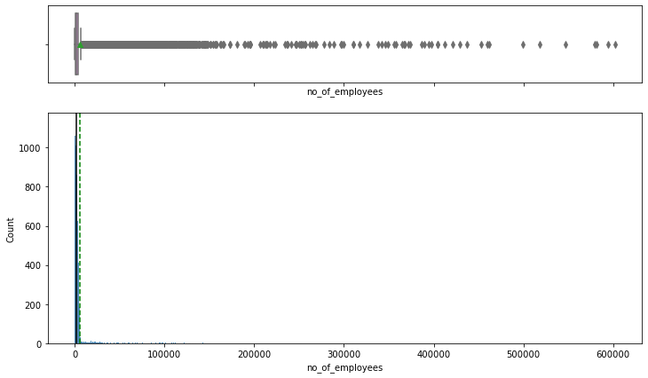

```python
histogram_boxplot(data,'no_of_employees')
```

```python
test = data.loc[(data['no_of_employees'] < 1)]
test.count()
```

```
continent                33
education_of_employee    33
has_job_experience       33
requires_job_training    33
no_of_employees          33
yr_of_estab              33
region_of_employment     33
prevailing_wage          33
unit_of_wage             33
full_time_position       33
case_status              33
dtype: int64
```

33 rows have values of listed number of employees as 0 or less.

```python
test = data[(data['no_of_employees'] < 1) ].index
data.drop(test, inplace=True)
data.info()
```

```
<class 'pandas.core.frame.DataFrame'>
Int64Index: 25447 entries, 0 to 25479
Data columns (total 11 columns):
 #   Column                 Non-Null Count  Dtype
---  ------                 --------------  -----
 0   continent              25447 non-null  category
 1   education_of_employee  25447 non-null  category
 2   has_job_experience     25447 non-null  category
 3   requires_job_training  25447 non-null  category
 4   no_of_employees        25447 non-null  int64
 5   yr_of_estab            25447 non-null  int64
 6   region_of_employment   25447 non-null  category
 7   prevailing_wage        25447 non-null  float64
 8   unit_of_wage           25447 non-null  category
 9   full_time_position     25447 non-null  category
 10  case_status            25447 non-null  category
dtypes: category(8), float64(1), int64(2)
memory usage: 995.3 KB
```

```python
test = data.loc[(data['no_of_employees'] < 1)]
test.count()
```

```
continent                0
education_of_employee    0
has_job_experience       0
requires_job_training    0
no_of_employees          0
yr_of_estab              0
region_of_employment     0
prevailing_wage          0
unit_of_wage             0
full_time_position       0
case_status              0
dtype: int64
```

The 33 rows of data were deleted successfully from the working dataframe.

```python
test = data.loc[(data['yr_of_estab'] < 1900)]
test
```

|  | continent | education_of_employee | has_job_experience | requires_job_training | no_of_employees | yr_of_estab | region_of_employment | prevailing_wage | unit_of_wage | full_time_position | case_status |
| --- | --- | --- | --- | --- | --- | --- | --- | --- | --- | --- | --- |
| 3 | Asia | Bachelor's | N | N | 98 | 1897 | West | 83434.030 | Year | Y | Denied |
| 23 | North America | High School | N | N | 1517 | 1884 | Midwest | 90108.380 | Year | N | Certified |
| 31 | Asia | Doctorate | Y | N | 995 | 1880 | South | 135866.130 | Year | N | Certified |
| 67 | Europe | Doctorate | Y | N | 2070 | 1847 | West | 5319.490 | Year | Y | Certified |
| 73 | Asia | Master's | Y | N | 452 | 1890 | South | 122540.550 | Year | Y | Certified |
| ... | ... | ... | ... | ... | ... | ... | ... | ... | ... | ... | ... |
| 25444 | South America | Master's | Y | N | 1081 | 1838 | Northeast | 156.607 | Hour | Y | Certified |
| 25445 | Asia | Bachelor's | Y | N | 2642 | 1890 | Northeast | 25899.990 | Year | Y | Certified |
| 25463 | Asia | High School | N | N | 444 | 1838 | Midwest | 213189.360 | Year | Y | Certified |
| 25467 | North America | Master's | N | Y | 2504 | 1882 | Northeast | 105900.660 | Year | Y | Certified |
| 25478 | Asia | Master's | Y | Y | 1918 | 1887 | West | 86154.770 | Year | Y | Certified |

2108 rows × 11 columns

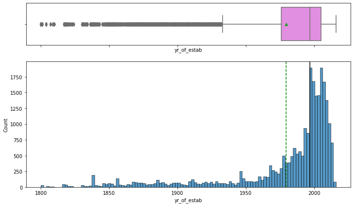

```python
histogram_boxplot(data,'yr_of_estab')
```

2108 companies were established priot to 1900 of the total dataset. Since the country was established in 1776, this is reasonable. No further action will be taken on this dataset at this time.

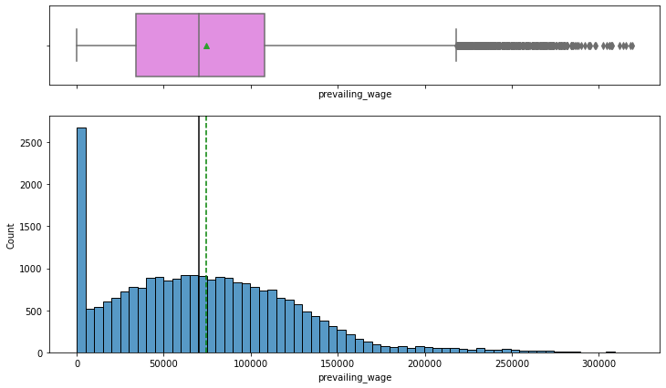

```python
histogram_boxplot(data,'prevailing_wage')
```

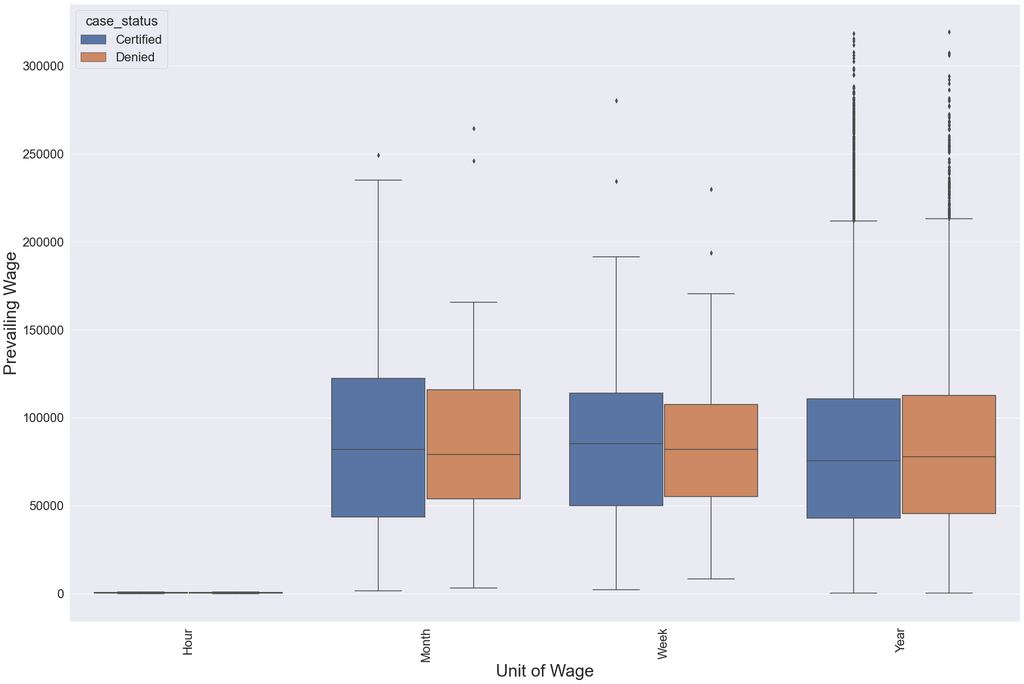

```python
sns.set(font_scale = 2)
ax = sns.boxplot(x="unit_of_wage", y="prevailing_wage", hue = "case_status", data=data)
ax.set_xticklabels(ax.get_xticklabels(),rotation = 90)
ax.set_xlabel("Unit of Wage", fontsize = 30)
ax.set_ylabel("Prevailing Wage", fontsize = 30)
sns.set(rc = {'figure.figsize':(30,20)})
plt.show()
```

```python
from IPython.display import display, HTML

test = data.loc[(data['prevailing_wage'] < 34000)]
pd.set_option("display.max_rows", None)
#display(HTML("<div style='height: 200px; overflow: auto; width: fit-content'>" +
#             test.to_html() +
#             "</div>"))
test.sort_values(by = 'prevailing_wage', ascending = False)
```

|  | continent | education_of_employee | has_job_experience | requires_job_training | no_of_employees | yr_of_estab | region_of_employment | prevailing_wage | unit_of_wage | full_time_position | case_status |
| --- | --- | --- | --- | --- | --- | --- | --- | --- | --- | --- | --- |
| 1273 | Europe | Doctorate | Y | N | 288 | 1972 | West | 33990.0500 | Year | Y | Certified |
| 8866 | Asia | Bachelor's | Y | N | 2711 | 2004 | South | 33989.5900 | Year | Y | Certified |
| 1028 | North America | Master's | N | N | 4528 | 1989 | West | 33987.1700 | Year | Y | Denied |
| 15097 | Asia | Bachelor's | N | Y | 3627 | 1968 | South | 33969.4900 | Year | Y | Denied |
| 12701 | Asia | Bachelor's | Y | Y | 77261 | 1911 | Northeast | 33968.7000 | Year | Y | Certified |
| 12235 | Asia | Bachelor's | N | N | 1516 | 2005 | West | 33962.2000 | Year | Y | Certified |
| 15997 | North America | High School | Y | N | 5046 | 1987 | Northeast | 33955.3800 | Year | Y | Certified |
| 25158 | Asia | Master's | Y | N | 3629 | 1968 | Northeast | 33946.3700 | Year | Y | Certified |
| 18443 | Asia | Doctorate | Y | N | 242 | 1865 | Midwest | 33935.8800 | Year | Y | Certified |
| 19387 | Europe | Doctorate | Y | N | 3011 | 2004 | West | 33931.0100 | Year | Y | Certified |
| 22524 | Asia | Bachelor's | Y | N | 4430 | 1997 | Northeast | 33929.9700 | Year | Y | Certified |
| 6239 | Oceania | Bachelor's | N | N | 2004 | 2014 | Midwest | 33917.0800 | Year | Y | Denied |
| 17515 | Europe | Master's | N | N | 57288 | 1981 | West | 33910.5800 | Year | Y | Certified |
| 4511 | Asia | Master's | Y | N | 1771 | 1923 | West | 33894.6700 | Year | Y | Certified |
| 25021 | Asia | Bachelor's | Y | N | 292 | 1998 | Northeast | 33892.9300 | Year | Y | Denied |
| 5293 | Asia | Master's | Y | N | 14858 | 2011 | Northeast | 33892.8600 | Year | N | Certified |
| 12589 | Asia | Master's | Y | N | 1592 | 1961 | West | 33884.1100 | Year | Y | Certified |
| 20686 | Asia | Master's | Y | N | 4611 | 1997 | Midwest | 33883.7700 | Year | Y | Certified |
| 20365 | Asia | Master's | Y | N | 122064 | 1909 | South | 33880.7300 | Year | Y | Certified |
| 2361 | Asia | Master's | N | N | 1503 | 2009 | Midwest | 33877.3400 | Year | Y | Certified |
| 2345 | Asia | Bachelor's | N | N | 1169 | 1997 | West | 33869.9800 | Year | Y | Denied |
| 9870 | Asia | Master's | Y | N | 145600 | 1897 | Northeast | 33868.2500 | Year | Y | Certified |
| 11883 | Europe | Bachelor's | N | N | 1057 | 1911 | West | 33867.1400 | Year | Y | Certified |
| 1839 | Asia | Bachelor's | N | N | 4505 | 1999 | West | 33857.5500 | Year | Y | Denied |
| 4876 | Europe | Master's | Y | N | 14912 | 1996 | South | 33854.3900 | Year | Y | Certified |
| 19496 | Asia | Master's | Y | N | 3510 | 1972 | South | 33849.1800 | Year | Y | Certified |
| 15664 | Asia | Bachelor's | Y | N | 234 | 1998 | Northeast | 33839.1200 | Year | Y | Certified |
| 14668 | Europe | Master's | N | N | 431 | 1838 | Midwest | 33833.6100 | Year | Y | Certified |
| 14110 | Asia | Bachelor's | N | N | 622 | 1997 | Northeast | 33827.4700 | Year | Y | Certified |
| 4558 | Europe | Master's | N | N | 3376 | 1998 | Northeast | 33826.5500 | Year | Y | Certified |

[output cut: 6328 more lines]

The lowest wage values are paid by hour, which makes them more reasonable.

## Exploratory Data Analysis (EDA)

- EDA is an important part of any project involving data.
- It is important to investigate and understand the data better before building a model with it.
- A few questions have been mentioned below which will help you approach the analysis in the right manner and generate insights from the data.
- A thorough analysis of the data, in addition to the questions mentioned below, should be done.

```python
# Univariate Analysis
def histogram_boxplot(data, feature, figsize=(12, 7), kde=False, bins=None):
    """
    Boxplot and histogram combined

    data: dataframe
    feature: dataframe column
    figsize: size of figure (default (12,7))
    kde: whether to the show density curve (default False)
    bins: number of bins for histogram (default None)
    """
    f2, (ax_box2, ax_hist2) = plt.subplots(
        nrows=2,  # Number of rows of the subplot grid= 2
        sharex=True,  # x-axis will be shared among all subplots
        gridspec_kw={"height_ratios": (0.25, 0.75)},
        figsize=figsize,
    )  # creating the 2 subplots
    sns.boxplot(
        data=data, x=feature, ax=ax_box2, showmeans=True, color="violet"
    )  # boxplot will be created and a star will indicate the mean value of the column
    sns.histplot(
        data=data, x=feature, kde=kde, ax=ax_hist2, bins=bins, palette="winter"
    ) if bins else sns.histplot(
        data=data, x=feature, kde=kde, ax=ax_hist2
    )  # For histogram
    ax_hist2.axvline(
        data[feature].mean(), color="green", linestyle="--"
    )  # Add mean to the histogram
    ax_hist2.axvline(
        data[feature].median(), color="black", linestyle="-"
    )  # Add median to the histogram
# function to create labeled barplots


def labeled_barplot(data, feature, perc=False, n=None):
    """
    Barplot with percentage at the top

    data: dataframe
    feature: dataframe column
    perc: whether to display percentages instead of count (default is False)
    n: displays the top n category levels (default is None, i.e., display all levels)
    """

    total = len(data[feature])  # length of the column
    count = data[feature].nunique()
    if n is None:
        plt.figure(figsize=(count + 2, 6))
    else:
        plt.figure(figsize=(n + 2, 6))

    plt.xticks(rotation=90, fontsize=15)
    ax = sns.countplot(
        data=data,
        x=feature,
        palette="Paired",
        order=data[feature].value_counts().index[:n].sort_values(),
    )

    for p in ax.patches:
        if perc == True:
            label = "{:.1f}%".format(
                100 * p.get_height() / total
            )  # percentage of each class of the category
        else:
            label = p.get_height()  # count of each level of the category

        x = p.get_x() + p.get_width() / 2  # width of the plot
        y = p.get_height()  # height of the plot

        ax.annotate(
            label,
            (x, y),
            ha="center",
            va="center",
            size=12,
            xytext=(0, 5),
            textcoords="offset points",
        )  # annotate the percentage

    plt.show()  # show the plot

def stacked_barplot(data, predictor, target):
    """
    Print the category counts and plot a stacked bar chart

    data: dataframe
    predictor: independent variable
    target: target variable
    """
    count = data[predictor].nunique()
    sorter = data[target].value_counts().index[-1]
    tab1 = pd.crosstab(data[predictor], data[target], margins=True).sort_values(
        by=sorter, ascending=False
    )
    print(tab1)
    print("-" * 120)
    tab = pd.crosstab(data[predictor], data[target], normalize="index").sort_values(
        by=sorter, ascending=False
    )
    tab.plot(kind="bar", stacked=True, figsize=(count + 5, 5))
    plt.legend(
        loc="lower left", frameon=False,
    )
    plt.legend(loc="upper left", bbox_to_anchor=(1, 1))
    plt.show()

### function to plot distributions wrt target


def distribution_plot_wrt_target(data, predictor, target):

    fig, axs = plt.subplots(2, 2, figsize=(12, 10))

    target_uniq = data[target].unique()

    axs[0, 0].set_title("Distribution of target for target=" + str(target_uniq[0]))
    sns.histplot(
        data=data[data[target] == target_uniq[0]],
        x=predictor,
        kde=True,
        ax=axs[0, 0],
        color="teal",
        stat="density",
    )

    axs[0, 1].set_title("Distribution of target for target=" + str(target_uniq[1]))
    sns.histplot(
        data=data[data[target] == target_uniq[1]],
        x=predictor,
        kde=True,
        ax=axs[0, 1],
        color="orange",
        stat="density",
    )

    axs[1, 0].set_title("Boxplot w.r.t target")
    sns.boxplot(data=data, x=target, y=predictor, ax=axs[1, 0], palette="gist_rainbow")

    axs[1, 1].set_title("Boxplot (without outliers) w.r.t target")
    sns.boxplot(
        data=data,
        x=target,
        y=predictor,
        ax=axs[1, 1],
        showfliers=False,
        palette="gist_rainbow",
    )

    plt.tight_layout()
    plt.show()
```

**Leading Questions**:

1. Those with higher education may want to travel abroad for a well-paid job. Does education play a role in Visa certification?
2. How does the visa status vary across different continents?
3. Experienced professionals might look abroad for opportunities to improve their lifestyles and career development. Does work experience influence visa status?
4. In the United States, employees are paid at different intervals. Which pay unit is most likely to be certified for a visa?
5. The US government has established a prevailing wage to protect local talent and foreign workers. How does the visa status change with the prevailing wage?

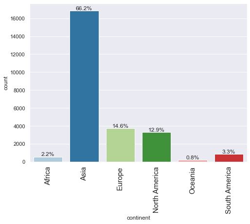

```python
labeled_barplot(data, "continent", perc=True)
```

The majority of those seeking to enter the US are from Asia by a wide margin.

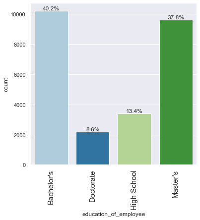

```python
labeled_barplot(data, "education_of_employee", perc=True)
```

Most potential immigrants have a Bachelors or Masters degree. Fewer have a Doctrate or High School level of education.

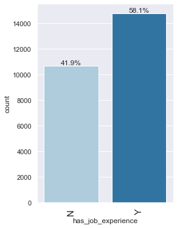

```python
labeled_barplot(data, "has_job_experience", perc=True)
```

Most potential immigrants have job experience. Some may be fresh out of college with no job experience yet.

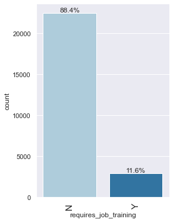

```python
labeled_barplot(data, "requires_job_training", perc=True)
```

The vast majority of potential immigrants do not require on the job training.

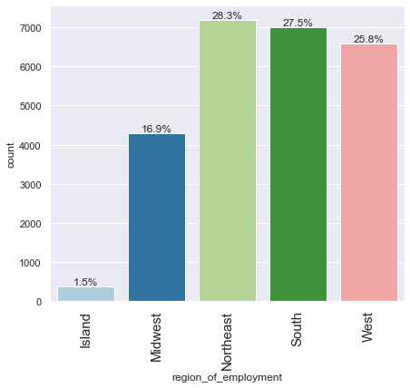

```python
labeled_barplot(data, "region_of_employment", perc=True)
```

Locations where potential immigrants are working is spread out similar to the population density of the USA.

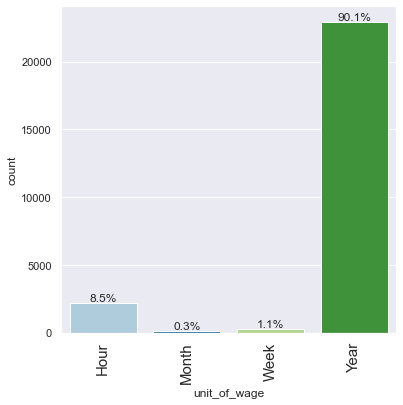

```python
labeled_barplot(data, "unit_of_wage", perc=True)
```

Most potential immigrants are being paid yearly, so most likely salary jobs. Some other jobs pay by the hour, month or week.

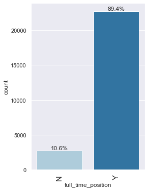

```python
labeled_barplot(data, "full_time_position", perc=True)
```

Most potential immigrants are looking at full time positions.

**Leading Questions**:

1. Those with higher education may want to travel abroad for a well-paid job. Does education play a role in Visa certification?

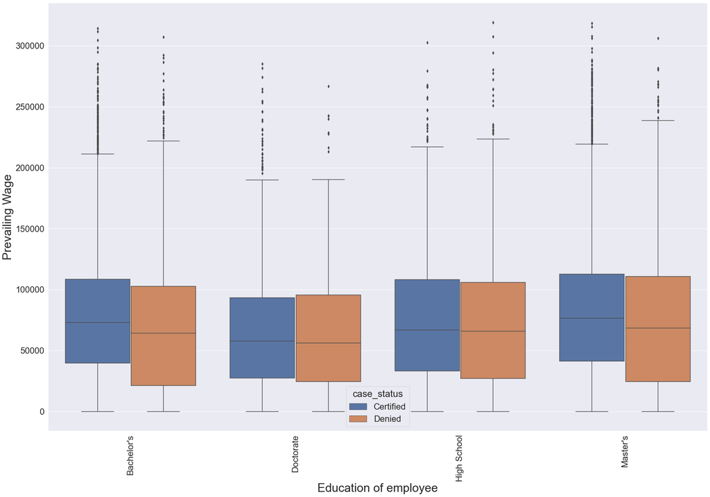

```python
sns.set(font_scale = 2)
ax = sns.boxplot(x="education_of_employee", y="prevailing_wage", hue = "case_status", data=data)
ax.set_xticklabels(ax.get_xticklabels(),rotation = 90)
ax.set_xlabel("Education of employee", fontsize = 30)
ax.set_ylabel("Prevailing Wage", fontsize = 30)
sns.set(rc = {'figure.figsize':(30,20)})
plt.show()
```

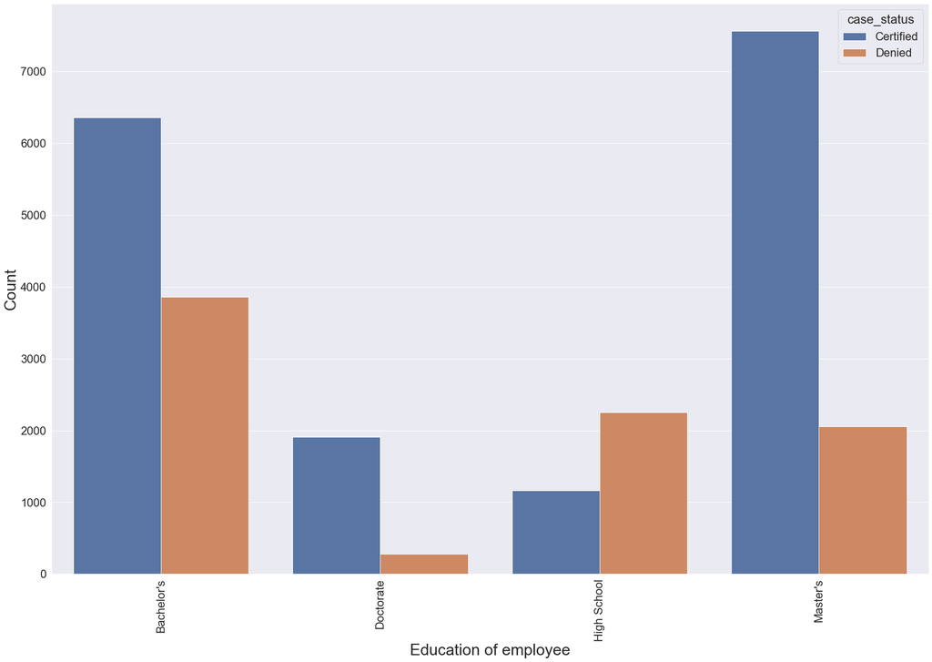

```python
sns.set(font_scale = 2)
ax = sns.countplot(x="education_of_employee",  hue = "case_status", data=data)
ax.set_xticklabels(ax.get_xticklabels(),rotation = 90)
ax.set_xlabel("Education of employee", fontsize = 30)
ax.set_ylabel("Count", fontsize = 30)
sns.set(rc = {'figure.figsize':(30,20)})
plt.show()
```

The graph above shows that as education increases, more of the applicants who reached a higher degree of education have been certified. High school educations shows the opposite trend, with more applicants denied rather than certified.

**Leading Questions**:

1. How does the visa status vary across different continents?

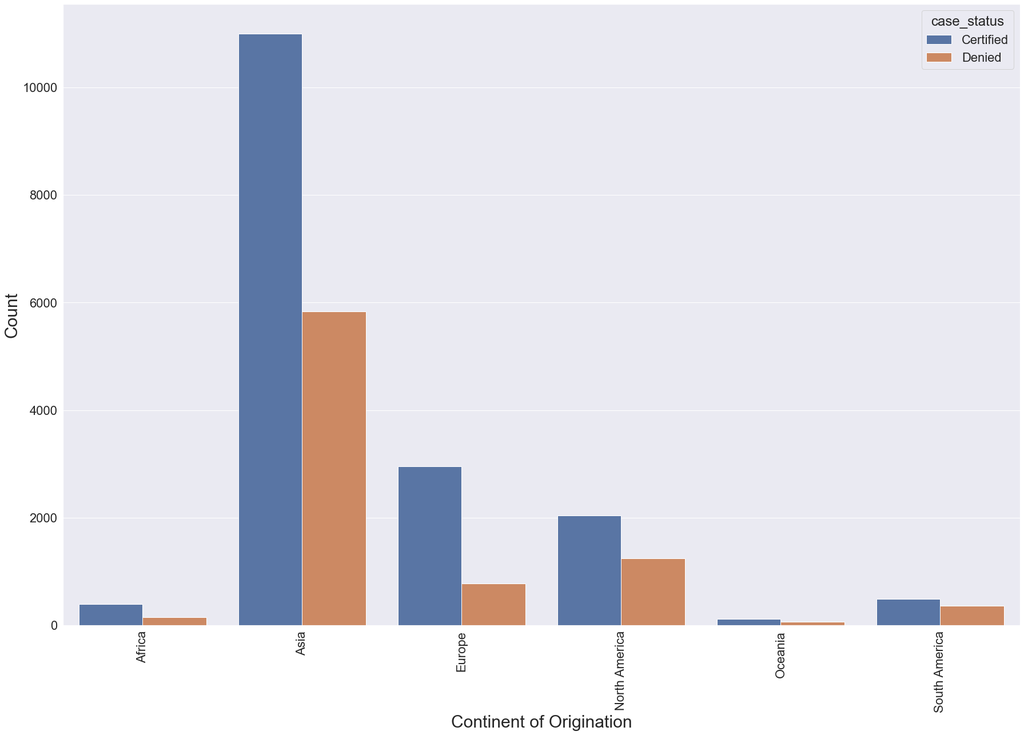

```python
sns.set(font_scale = 2)
ax = sns.countplot(x="continent",  hue = "case_status", data=data)
ax.set_xticklabels(ax.get_xticklabels(),rotation = 90)
ax.set_xlabel("Continent of Origination", fontsize = 30)
ax.set_ylabel("Count", fontsize = 30)
sns.set(rc = {'figure.figsize':(30,20)})
plt.show()
```

Most visa applicants are from Asia with Europe being the second highest continent followed by North America.

**Leading Questions**:

1. Experienced professionals might look abroad for opportunities to improve their lifestyles and career development. Does work experience influence visa status?

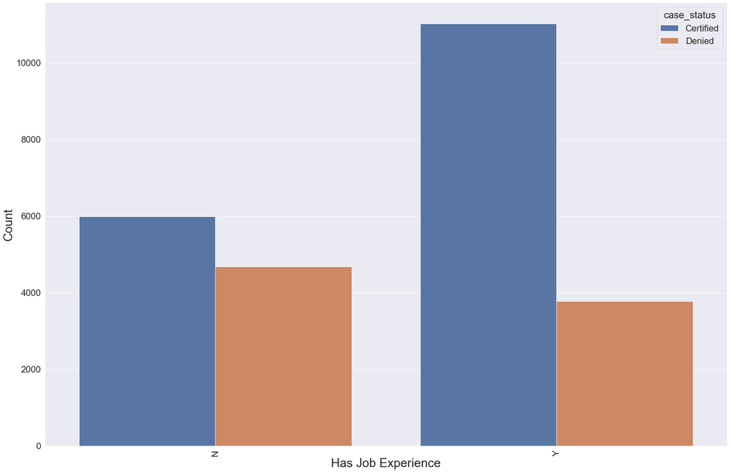

```python
sns.set(font_scale = 2)
ax = sns.countplot(x="has_job_experience",  hue = "case_status", data=data)
ax.set_xticklabels(ax.get_xticklabels(),rotation = 90)
ax.set_xlabel("Has Job Experience", fontsize = 30)
ax.set_ylabel("Count", fontsize = 30)
sns.set(rc = {'figure.figsize':(30,20)})
plt.show()
```

Applicants with job Experience have more certifications than applicants with no job experience.

**Leading Questions**:

1. In the United States, employees are paid at different intervals. Which pay unit is most likely to be certified for a visa?

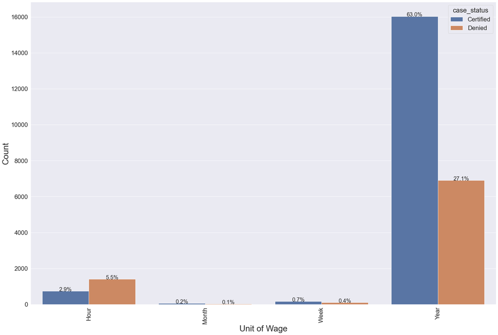

```python
sns.set(font_scale = 2)
ax = sns.countplot(x="unit_of_wage",  hue = "case_status", data=data)
ax.set_xticklabels(ax.get_xticklabels(),rotation = 90)
ax.set_xlabel("Unit of Wage", fontsize = 30)
ax.set_ylabel("Count", fontsize = 30)
perc = False
total = len(data['unit_of_wage'])  # length of the column
for p in ax.patches:
    label = "{:.1f}%".format(100 * p.get_height() / total)
    x = p.get_x() + p.get_width() / 2  # width of the plot
    y = p.get_height()  # height of the plot
    ax.annotate(label, (x, y), ha="center",va="center",size=20,xytext=(0, 5),
                textcoords="offset points")  # annotate the percentage

sns.set(rc = {'figure.figsize':(30,20)})
plt.show()
```

**Leading Questions**:

1. The US government has established a prevailing wage to protect local talent and foreign workers. How does the visa status change with the prevailing wage?

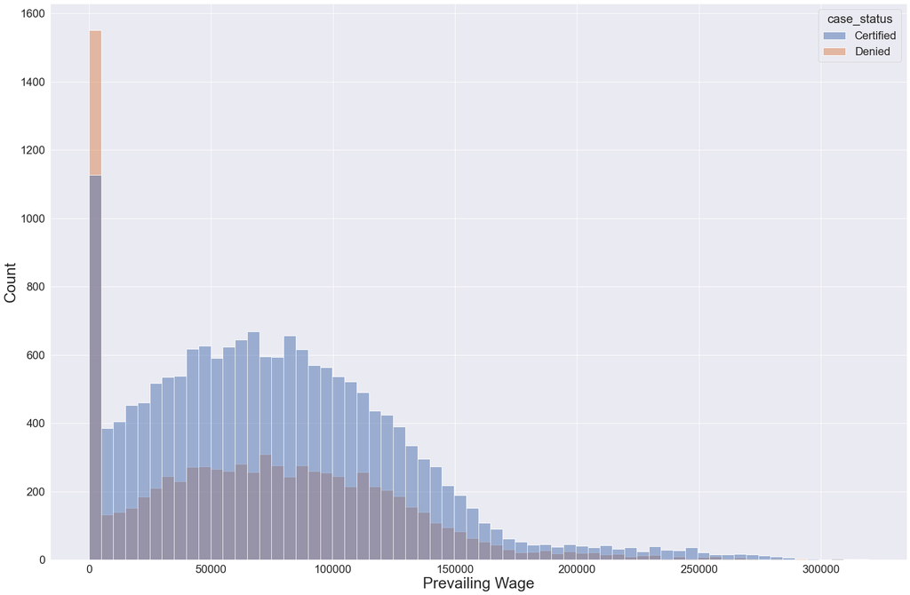

```python
sns.set(font_scale = 2)
ax = sns.histplot(x="prevailing_wage",  hue = "case_status", data=data)
#ax.set_xticklabels(ax.get_xticklabels(),rotation = 90)
ax.set_xlabel("Prevailing Wage", fontsize = 30)
ax.set_ylabel("Count", fontsize = 30)
sns.set(rc = {'figure.figsize':(30,20)})
plt.show()
```

From 0 - 5000 of wage the cases that are denied are higher than those that are certified. For each bin of prevailing wager higher, the cases certified exceed the cases denied.

## Data Preprocessing

- Missing value treatment (if needed)
- Feature engineering
- Outlier detection and treatment (if needed)
- Preparing data for modeling
- Any other preprocessing steps (if needed)

```python
print(data.continent.value_counts())
print(data.education_of_employee.value_counts())
print(data.has_job_experience.value_counts())
print(data.requires_job_training.value_counts())
print(data.region_of_employment.value_counts())
print(data.unit_of_wage.value_counts())
print(data.full_time_position.value_counts())
print(data.case_status.value_counts())
```

```
Asia             16840
Europe            3727
North America     3287
South America      851
Africa             550
Oceania            192
Name: continent, dtype: int64
Bachelor's     10220
Master's        9622
High School     3416
Doctorate       2189
Name: education_of_employee, dtype: int64
Y    14786
N    10661
Name: has_job_experience, dtype: int64
N    22498
Y     2949
Name: requires_job_training, dtype: int64
Northeast    7189
South        7006
West         6578
Midwest      4299
Island        375
Name: region_of_employment, dtype: int64
Year     22933
Hour      2153
Week       272
Month       89
Name: unit_of_wage, dtype: int64
Y    22741
N     2706
Name: full_time_position, dtype: int64
Certified    17001
Denied        8446
Name: case_status, dtype: int64
```

```python
replaceStruct = {
                "continent":     {"Asia": 1, "Europe": 2 ,"North America": 3 ,"South America":4, "Africa":5,
                                 "Oceania":6},
                "education_of_employee": {"High School": 1, "Bachelor's":2 , "Master's": 3, "Doctorate": 4},
                "has_job_experience": {"N":0, "Y":1},
                "requires_job_training": {"N":0, "Y":1},
                "region_of_employment":     {"Northeast": 1, "South": 2 ,"West": 3 ,"Midwest": 4 ,"Island": 5},
                "unit_of_wage":     {"Hour": 1, "Week": 2, "Month":3, "Year":4 },
                "full_time_position":     {"N": 0, "Y": 1 },
                "case_status":     {"Denied": 0, "Certified": 1 }}
oneHotCols=["continent","education_of_employee", "region_of_employment",
           "unit_of_wage"]
```

```python
datap = data.copy()
datap=datap.replace(replaceStruct)
datap=pd.get_dummies(datap, columns=oneHotCols)
datap.head(10)
```

|  | has_job_experience | requires_job_training | no_of_employees | yr_of_estab | prevailing_wage | full_time_position | case_status | continent_1 | continent_2 | continent_3 | ... | education_of_employee_4 | region_of_employment_1 | region_of_employment_2 | region_of_employment_3 | region_of_employment_4 | region_of_employment_5 | unit_of_wage_1 | unit_of_wage_2 | unit_of_wage_3 | unit_of_wage_4 |
| --- | --- | --- | --- | --- | --- | --- | --- | --- | --- | --- | --- | --- | --- | --- | --- | --- | --- | --- | --- | --- | --- |
| 0 | 0 | 0 | 14513 | 2007 | 592.2029 | 1 | 0 | 1 | 0 | 0 | ... | 0 | 0 | 0 | 1 | 0 | 0 | 1 | 0 | 0 | 0 |
| 1 | 1 | 0 | 2412 | 2002 | 83425.6500 | 1 | 1 | 1 | 0 | 0 | ... | 0 | 1 | 0 | 0 | 0 | 0 | 0 | 0 | 0 | 1 |
| 2 | 0 | 1 | 44444 | 2008 | 122996.8600 | 1 | 0 | 1 | 0 | 0 | ... | 0 | 0 | 0 | 1 | 0 | 0 | 0 | 0 | 0 | 1 |
| 3 | 0 | 0 | 98 | 1897 | 83434.0300 | 1 | 0 | 1 | 0 | 0 | ... | 0 | 0 | 0 | 1 | 0 | 0 | 0 | 0 | 0 | 1 |
| 4 | 1 | 0 | 1082 | 2005 | 149907.3900 | 1 | 1 | 0 | 0 | 0 | ... | 0 | 0 | 1 | 0 | 0 | 0 | 0 | 0 | 0 | 1 |
| 5 | 1 | 0 | 2339 | 2012 | 78252.1400 | 1 | 1 | 1 | 0 | 0 | ... | 0 | 0 | 1 | 0 | 0 | 0 | 0 | 0 | 0 | 1 |
| 6 | 0 | 0 | 4985 | 1994 | 53635.3900 | 1 | 1 | 1 | 0 | 0 | ... | 0 | 0 | 1 | 0 | 0 | 0 | 0 | 0 | 0 | 1 |
| 7 | 1 | 0 | 3035 | 1924 | 418.2298 | 1 | 0 | 0 | 0 | 1 | ... | 0 | 0 | 0 | 1 | 0 | 0 | 1 | 0 | 0 | 0 |
| 8 | 0 | 0 | 4810 | 2012 | 74362.1900 | 1 | 1 | 1 | 0 | 0 | ... | 0 | 0 | 0 | 0 | 1 | 0 | 0 | 0 | 0 | 1 |
| 9 | 1 | 0 | 2251 | 1995 | 67514.7600 | 1 | 1 | 0 | 1 | 0 | ... | 1 | 0 | 1 | 0 | 0 | 0 | 0 | 0 | 0 | 1 |

10 rows × 26 columns

```python
datap.info()
```

```
<class 'pandas.core.frame.DataFrame'>
Int64Index: 25447 entries, 0 to 25479
Data columns (total 26 columns):
 #   Column                   Non-Null Count  Dtype
---  ------                   --------------  -----
 0   has_job_experience       25447 non-null  int64
 1   requires_job_training    25447 non-null  int64
 2   no_of_employees          25447 non-null  int64
 3   yr_of_estab              25447 non-null  int64
 4   prevailing_wage          25447 non-null  float64
 5   full_time_position       25447 non-null  int64
 6   case_status              25447 non-null  int64
 7   continent_1              25447 non-null  uint8
 8   continent_2              25447 non-null  uint8
 9   continent_3              25447 non-null  uint8
```

[output cut: 18 more lines]

## EDA

- It is a good idea to explore the data once again after manipulating it.

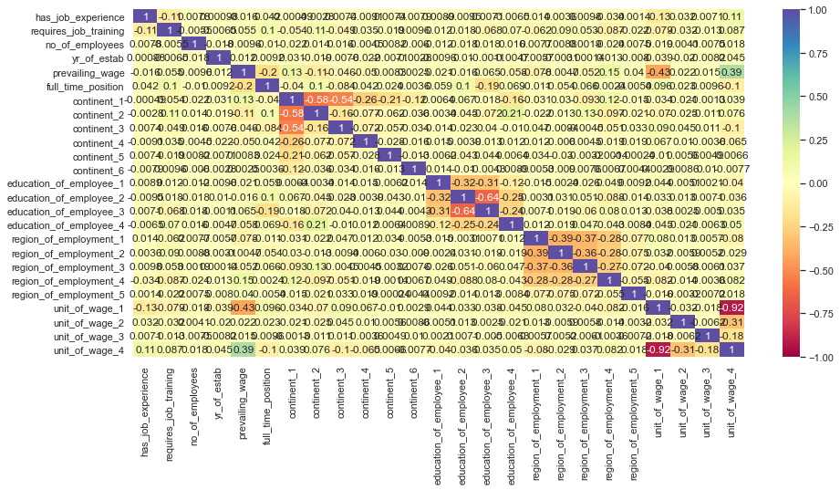

```python
plt.figure(figsize=(15, 7))
sns.heatmap(datap.corr(), annot=True, vmin=-1, vmax=1, cmap="Spectral")
plt.show()
```

Some high negative correlations between unit of wage 1 (Hour) and unit of wage 4 (Year).

## Building bagging and boosting models

```python
X = datap.drop("case_status" , axis=1)
y = datap.pop("case_status")
```

```python
X_train, X_test, y_train, y_test = train_test_split(X, y, test_size=.30, random_state=1,stratify=y)
```

The dataset is unevenly distributed so we do need to stratify the data while splitting into testing and training sets.

```python
## Function to create confusion matrix
def make_confusion_matrix(model,y_actual,labels=[1, 0]):
    '''
    model : classifier to predict values of X
    y_actual : ground truth

    '''
    y_predict = model.predict(X_test)
    cm=metrics.confusion_matrix( y_actual, y_predict, labels=[0, 1])
    df_cm = pd.DataFrame(cm, index = [i for i in ["Actual - No","Actual - Yes"]],
                  columns = [i for i in ['Predicted - No','Predicted - Yes']])
    group_counts = ["{0:0.0f}".format(value) for value in
                cm.flatten()]
    group_percentages = ["{0:.2%}".format(value) for value in
                         cm.flatten()/np.sum(cm)]
    labels = [f"{v1}\n{v2}" for v1, v2 in
              zip(group_counts,group_percentages)]
    labels = np.asarray(labels).reshape(2,2)
    plt.figure(figsize = (10,7))
    sns.heatmap(df_cm, annot=labels,fmt='')
    plt.ylabel('True label')
    plt.xlabel('Predicted label')
    ##  Function to calculate different metric scores of the model - Accuracy, Recall and Precision
def get_metrics_score(model,flag=True):
    '''
    model : classifier to predict values of X

    '''
    # defining an empty list to store train and test results
    score_list=[]

    #Predicting on train and tests
    pred_train = model.predict(X_train)
    pred_test = model.predict(X_test)

    #Accuracy of the model
    train_acc = model.score(X_train,y_train)
    test_acc = model.score(X_test,y_test)

    #Recall of the model
    train_recall = metrics.recall_score(y_train,pred_train)
    test_recall = metrics.recall_score(y_test,pred_test)

    #Precision of the model
    train_precision = metrics.precision_score(y_train,pred_train)
    test_precision = metrics.precision_score(y_test,pred_test)

    score_list.extend((train_acc,test_acc,train_recall,test_recall,train_precision,test_precision))

    # If the flag is set to True then only the following print statements will be dispayed. The default value is set to True.
    if flag == True:
        print("Accuracy on training set : ",model.score(X_train,y_train))
        print("Accuracy on test set : ",model.score(X_test,y_test))
        print("Recall on training set : ",metrics.recall_score(y_train,pred_train))
        print("Recall on test set : ",metrics.recall_score(y_test,pred_test))
        print("Precision on training set : ",metrics.precision_score(y_train,pred_train))
        print("Precision on test set : ",metrics.precision_score(y_test,pred_test))

    return score_list # returning the list with train and test scores
## Function to create confusion matrix
def make_confusion_matrix(model,y_actual,labels=[1, 0]):
    '''
    model : classifier to predict values of X
    y_actual : ground truth

    '''
    y_predict = model.predict(X_test)
    cm=metrics.confusion_matrix( y_actual, y_predict, labels=[0, 1])
    df_cm = pd.DataFrame(cm, index = [i for i in ["Actual - No","Actual - Yes"]],
                  columns = [i for i in ['Predicted - No','Predicted - Yes']])
    group_counts = ["{0:0.0f}".format(value) for value in
                cm.flatten()]
    group_percentages = ["{0:.2%}".format(value) for value in
                         cm.flatten()/np.sum(cm)]
    labels = [f"{v1}\n{v2}" for v1, v2 in
              zip(group_counts,group_percentages)]
    labels = np.asarray(labels).reshape(2,2)
    plt.figure(figsize = (10,7))
    sns.heatmap(df_cm, annot=labels,fmt='')
    plt.ylabel('True label')
    plt.xlabel('Predicted label')
##  Function to calculate different metric scores of the model - Accuracy, Recall and Precision
def get_metrics_score(model,flag=True):
    '''
    model : classifier to predict values of X

    '''
    # defining an empty list to store train and test results
    score_list=[]

    pred_train = model.predict(X_train)
    pred_test = model.predict(X_test)

    train_acc = model.score(X_train,y_train)
    test_acc = model.score(X_test,y_test)

    train_recall = metrics.recall_score(y_train,pred_train)
    test_recall = metrics.recall_score(y_test,pred_test)

    train_precision = metrics.precision_score(y_train,pred_train)
    test_precision = metrics.precision_score(y_test,pred_test)

    score_list.extend((train_acc,test_acc,train_recall,test_recall,train_precision,test_precision))

    # If the flag is set to True then only the following print statements will be dispayed. The default value is set to True.
    if flag == True:
        print("Accuracy on training set : ",model.score(X_train,y_train))
        print("Accuracy on test set : ",model.score(X_test,y_test))
        print("Recall on training set : ",metrics.recall_score(y_train,pred_train))
        print("Recall on test set : ",metrics.recall_score(y_test,pred_test))
        print("Precision on training set : ",metrics.precision_score(y_train,pred_train))
        print("Precision on test set : ",metrics.precision_score(y_test,pred_test))

    return score_list # returning the list with train and test scores
```

## Building the model

- We are going to build 2 ensemble models here - Bagging Classifier and Random Forest Classifier.
- First, let's build these models with default parameters and then use hyperparameter tuning to optimize the model performance.
- We will calculate all three metrics - Accuracy, Precision and Recall.

### Bagging

```python
#base_estimator for bagging classifier is a decision tree by default
bagging_estimator=BaggingClassifier(random_state=1)
bagging_estimator.fit(X_train,y_train)
```

```
BaggingClassifier(random_state=1)
```

```python
#Using above defined function to get accuracy, recall and precision on train and test set
bagging_estimator_score=get_metrics_score(bagging_estimator)
```

```
Accuracy on training set :  0.9856276667415226
Accuracy on test set :  0.695743287491814
Recall on training set :  0.9864705882352941
Recall on test set :  0.7753381689864732
Precision on training set :  0.9919722832516478
Precision on test set :  0.7706547155105222
```

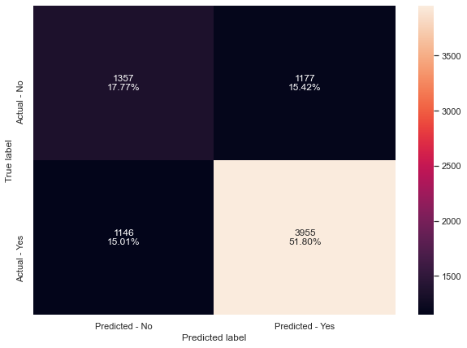

```python
make_confusion_matrix(bagging_estimator,y_test)
```

This model seems to be overfitting the data on the training set. Perhaps improving with adjusting hyperparameters will help.

### Random Forest Classifier

```python
#Train the random forest classifier
rf_estimator=RandomForestClassifier(random_state=1)
rf_estimator.fit(X_train,y_train)
```

```
RandomForestClassifier(random_state=1)
```

```python
#Using above defined function to get accuracy, recall and precision on train and test set
rf_estimator_score=get_metrics_score(rf_estimator)
```

```
Accuracy on training set :  0.9999438580732091
Accuracy on test set :  0.7176162409954159
Recall on training set :  1.0
Recall on test set :  0.8280729268770829
Precision on training set :  0.9999159734476094
Precision on test set :  0.7675813192803925
```

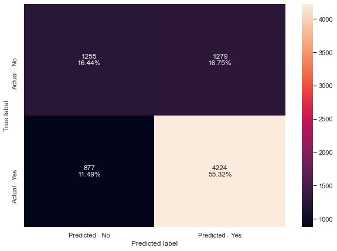

```python
make_confusion_matrix(rf_estimator,y_test)
```

This model seems to be overfitting the data on the training set. Perhaps improving with adjusting hyperparameters will help.

### AdaBoost Classifier

```python
abc = AdaBoostClassifier(random_state=1)
abc.fit(X_train,y_train)
```

```
AdaBoostClassifier(random_state=1)
```

```python
#Using above defined function to get accuracy, recall and precision on train and test set
abc_score=get_metrics_score(abc)
```

```
Accuracy on training set :  0.7389961823489782
Accuracy on test set :  0.7341191879502292
Recall on training set :  0.8894957983193277
Recall on test set :  0.8784552048617918
Precision on training set :  0.7604712982254472
Precision on test set :  0.760651841792565
```

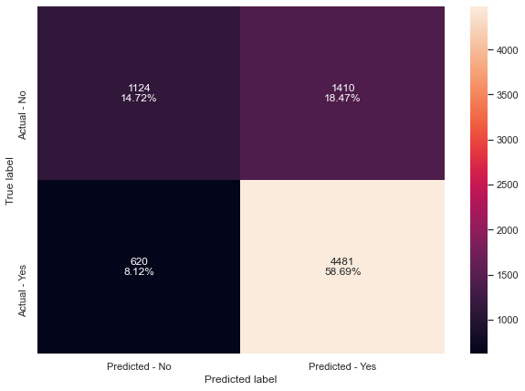

```python
make_confusion_matrix(abc,y_test)
```

Very good match with no overfitting on all scores. We will continue with hyperparameter fitting to see if we can improve the precision of the model.

### Gradient Boosting Classifier

```python
gbc = GradientBoostingClassifier(random_state=1)
gbc.fit(X_train,y_train)
```

```
GradientBoostingClassifier(random_state=1)
```

```python
#Using above defined function to get accuracy, recall and precision on train and test set
gbc_score=get_metrics_score(gbc)
```

```
Accuracy on training set :  0.7565124635077476
Accuracy on test set :  0.7469548133595285
Recall on training set :  0.8794117647058823
Recall on test set :  0.866300725347971
Precision on training set :  0.7828981820902222
Precision on test set :  0.7795025577703298
```

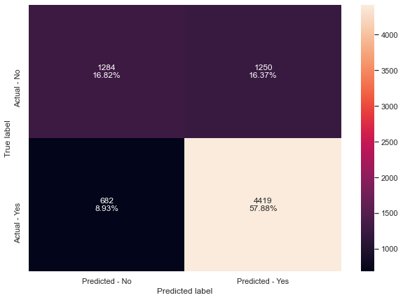

```python
make_confusion_matrix(gbc,y_test)
```

Very good match with no overfitting on all scores. We will continue with hyperparameter fitting to see if we can improve the precision of the model.

### XGBoost Classifier

```python
xgb = XGBClassifier(random_state=1,eval_metric='logloss')
xgb.fit(X_train,y_train)
```

```
XGBClassifier(base_score=0.5, booster='gbtree', callbacks=None,
              colsample_bylevel=1, colsample_bynode=1, colsample_bytree=1,
              early_stopping_rounds=None, enable_categorical=False,
              eval_metric='logloss', gamma=0, gpu_id=-1,
              grow_policy='depthwise', importance_type=None,
              interaction_constraints='', learning_rate=0.300000012,
              max_bin=256, max_cat_to_onehot=4, max_delta_step=0, max_depth=6,
              max_leaves=0, min_child_weight=1, missing=nan,
              monotone_constraints='()', n_estimators=100, n_jobs=0,
              num_parallel_tree=1, predictor='auto', random_state=1,
              reg_alpha=0, reg_lambda=1, ...)
```

```python
#Using above defined function to get accuracy, recall and precision on train and test set
xgb_score=get_metrics_score(xgb)
```

```
Accuracy on training set :  0.8321917808219178
Accuracy on test set :  0.7358218729535037
Recall on training set :  0.92890756302521
Recall on test set :  0.8590472456381102
Precision on training set :  0.8376146093809199
Precision on test set :  0.7714788732394366
```

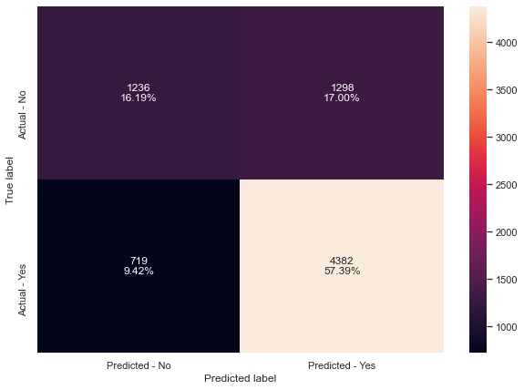

```python
make_confusion_matrix(xgb,y_test)
```

This appears to be overfitting the data. Not as good results as other boosting models. Perhaps tuning the hyperparameters will fix the overfitting.

## Will tuning the hyperparameters improve the model performance?

### Bagging

```python
# Choose the type of classifier.
bagging_estimator_tuned = BaggingClassifier(random_state=1)

# Grid of parameters to choose from
## add from article
parameters = {'max_samples': [0.7,0.8,0.9,1],
              'max_features': [0.7,0.8,0.9,1],
              'n_estimators' : [10,20,30,40,50],
             }

# Type of scoring used to compare parameter combinations
acc_scorer = metrics.make_scorer(metrics.recall_score)

# Run the grid search
grid_obj = GridSearchCV(bagging_estimator_tuned, parameters, scoring=acc_scorer,cv=5)
grid_obj = grid_obj.fit(X_train, y_train)

# Set the clf to the best combination of parameters
bagging_estimator_tuned = grid_obj.best_estimator_

# Fit the best algorithm to the data.
bagging_estimator_tuned.fit(X_train, y_train)
```

```
BaggingClassifier(max_features=0.7, max_samples=1, random_state=1)
```

```python
#Using above defined function to get accuracy, recall and precision on train and test set
bagging_estimator_tuned_score=get_metrics_score(bagging_estimator_tuned)
```

```
Accuracy on training set :  0.6680889288120369
Accuracy on test set :  0.6681074001309758
Recall on training set :  1.0
Recall on test set :  1.0
Precision on training set :  0.6680889288120369
Precision on test set :  0.6681074001309758
```

```python
make_confusion_matrix(bagging_estimator_tuned,y_test)
```

[output not shown]

By tuning the hyperparameters we have reduced overfitting of the data now that the training and test sets match so well. We have improved our recall to 1 at the cost of precision and accuracy.

```python
bagging_lr=BaggingClassifier(base_estimator=LogisticRegression(solver='liblinear',random_state=1,max_iter=1000),random_state=1)
bagging_lr.fit(X_train,y_train)
```

```
BaggingClassifier(base_estimator=LogisticRegression(max_iter=1000,
                                                    random_state=1,
                                                    solver='liblinear'),
                  random_state=1)
```

```python
#Using above defined function to get accuracy, recall and precision on train and test set
bagging_lr_score=get_metrics_score(bagging_lr)
```

```
Accuracy on training set :  0.6680889288120369
Accuracy on test set :  0.6681074001309758
Recall on training set :  1.0
Recall on test set :  1.0
Precision on training set :  0.6680889288120369
Precision on test set :  0.6681074001309758
```

```python
make_confusion_matrix(bagging_lr,y_test)
```

[output not shown]

Logistic Regression tuning significantly reduces the overfitting in the data. By tuning the hyperparameters we have reduced overfitting of the data now that the training and test sets match so well. We have improved our recall to 1 at the cost of precision and accuracy.

### Random Forest Classifier

```python
# Choose the type of classifier.
rf_estimator_tuned = RandomForestClassifier(random_state=1)

# Grid of parameters to choose from
## add from article
parameters = {"n_estimators": [150,200,250],
    "min_samples_leaf": np.arange(5, 10),
    "max_features": np.arange(0.2, 0.7, 0.1),
    "max_samples": np.arange(0.3, 0.7, 0.1),
             }

# Type of scoring used to compare parameter combinations
acc_scorer = metrics.make_scorer(metrics.recall_score)

# Run the grid search
grid_obj = GridSearchCV(rf_estimator_tuned, parameters, scoring=acc_scorer,cv=5)
grid_obj = grid_obj.fit(X_train, y_train)

# Set the clf to the best combination of parameters
rf_estimator_tuned = grid_obj.best_estimator_

# Fit the best algorithm to the data.
rf_estimator_tuned.fit(X_train, y_train)
```

```
RandomForestClassifier(max_features=0.2, max_samples=0.3, min_samples_leaf=7,
                       n_estimators=250, random_state=1)
```

```python
#Using above defined function to get accuracy, recall and precision on train and test set
rf_estimator_tuned_score=get_metrics_score(rf_estimator_tuned)
```

```
Accuracy on training set :  0.7613968111385583
Accuracy on test set :  0.7489194499017682
Recall on training set :  0.8841176470588236
Recall on test set :  0.8704175651832974
Precision on training set :  0.7856182795698925
Precision on test set :  0.7794943820224719
```

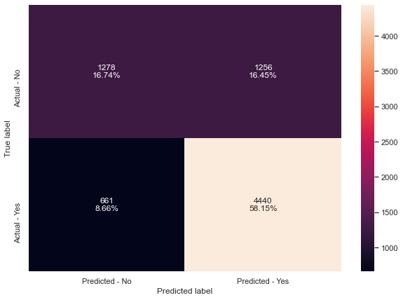

```python
make_confusion_matrix(rf_estimator_tuned,y_test)
```

This is a good model that reduces the overfitting of the original model. There is a much better match between training and test datasets.

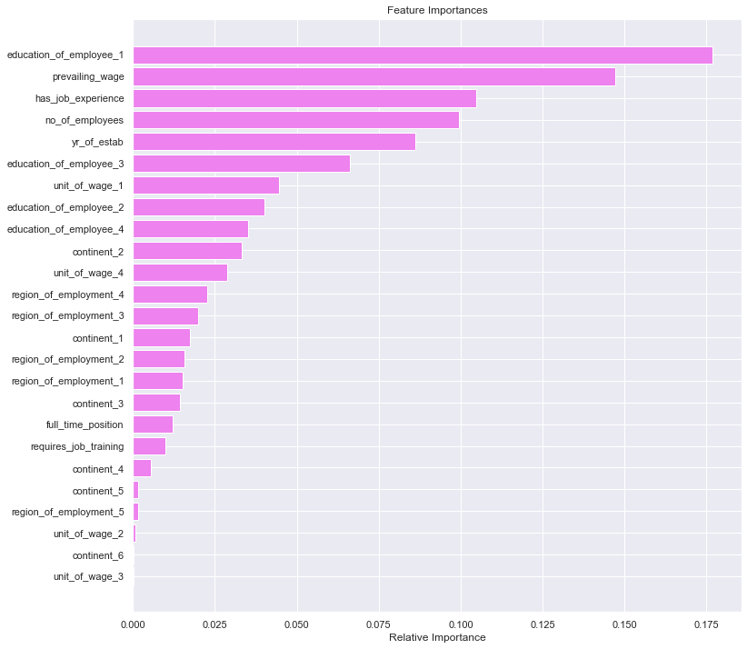

```python
importances = rf_estimator_tuned.feature_importances_
indices = np.argsort(importances)
feature_names = list(X.columns)

plt.figure(figsize=(12,12))
plt.title('Feature Importances')
plt.barh(range(len(indices)), importances[indices], color='violet', align='center')
plt.yticks(range(len(indices)), [feature_names[i] for i in indices])
plt.xlabel('Relative Importance')
plt.show()
```

Education, Prevailing Wage, and Job Experience are the top 3 columns for importance.

### AdaBoost Classifier

```python
# Choose the type of classifier.
abc_tuned = AdaBoostClassifier(random_state=1)

# Grid of parameters to choose from
## add from article
parameters = {
    #Let's try different max_depth for base_estimator
    "base_estimator":[DecisionTreeClassifier(max_depth=1, random_state=1),DecisionTreeClassifier(max_depth=2, random_state=1),DecisionTreeClassifier(max_depth=3, random_state=1)],
    "n_estimators": np.arange(10,110,10),
    "learning_rate":np.arange(0.1,2,0.1)
}

# Type of scoring used to compare parameter combinations
acc_scorer = metrics.make_scorer(metrics.recall_score)

# Run the grid search
grid_obj = GridSearchCV(abc_tuned, parameters, scoring=acc_scorer,cv=5)
grid_obj = grid_obj.fit(X_train, y_train)

# Set the clf to the best combination of parameters
abc_tuned = grid_obj.best_estimator_

# Fit the best algorithm to the data.
abc_tuned.fit(X_train, y_train)
```

```
AdaBoostClassifier(base_estimator=DecisionTreeClassifier(max_depth=1,
                                                         random_state=1),
                   learning_rate=0.1, n_estimators=20, random_state=1)
```

```python
#Using above defined function to get accuracy, recall and precision on train and test set
abc_tuned_score=get_metrics_score(abc_tuned)
```

```
Accuracy on training set :  0.6913316865034808
Accuracy on test set :  0.6914210870988867
Recall on training set :  0.9725210084033613
Recall on test set :  0.9698098412076064
Precision on training set :  0.6911729574773053
Precision on test set :  0.6919848929920268
```

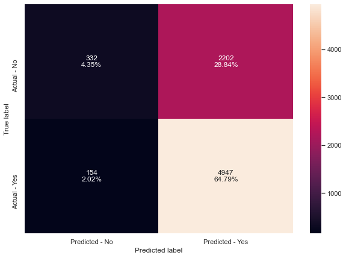

```python
make_confusion_matrix(abc_tuned,y_test)
```

This model significantly reduces the overfitting prior to tuning. We get close to 1 with the Recall and 69 for both Accuracy and Precision

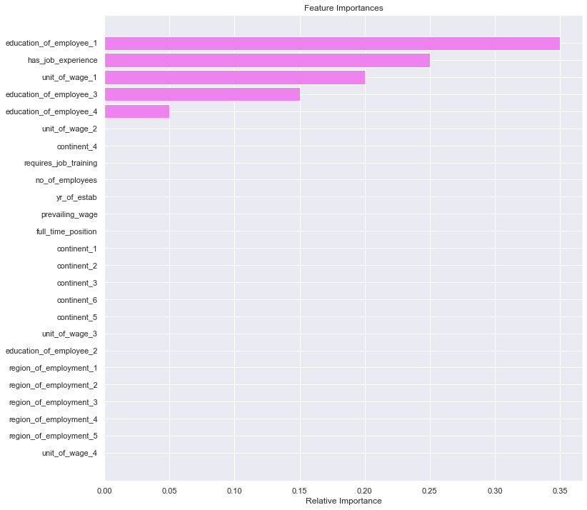

```python
importances = abc_tuned.feature_importances_
indices = np.argsort(importances)
feature_names = list(X.columns)

plt.figure(figsize=(12,12))
plt.title('Feature Importances')
plt.barh(range(len(indices)), importances[indices], color='violet', align='center')
plt.yticks(range(len(indices)), [feature_names[i] for i in indices])
plt.xlabel('Relative Importance')
plt.show()
```

Education, Job experience and Unit of wage top the list for most important features using the AdaBoost model.

### Gradient Boosting Classifier

```python
gbc_init = GradientBoostingClassifier(init=AdaBoostClassifier(random_state=1),random_state=1)
gbc_init.fit(X_train,y_train)
```

```
GradientBoostingClassifier(init=AdaBoostClassifier(random_state=1),
                           random_state=1)
```

```python
#Using above defined function to get accuracy, recall and precision on train and test set
gbc_init_score=get_metrics_score(gbc_init)
```

```
Accuracy on training set :  0.7562878958005839
Accuracy on test set :  0.7462999345121153
Recall on training set :  0.8792436974789916
Recall on test set :  0.865320525387179
Precision on training set :  0.7827485598862871
Precision on test set :  0.7793079096045198
```

```python
# Choose the type of classifier.
gbc_tuned = GradientBoostingClassifier(init=AdaBoostClassifier(random_state=1),random_state=1)

# Grid of parameters to choose from
## add from article
parameters = {
    "n_estimators": [100,150,200,250],
    "subsample":[0.8,0.9,1],
    "max_features":[0.7,0.8,0.9,1]
}

# Type of scoring used to compare parameter combinations
acc_scorer = metrics.make_scorer(metrics.recall_score)

# Run the grid search
grid_obj = GridSearchCV(gbc_tuned, parameters, scoring=acc_scorer,cv=5)
grid_obj = grid_obj.fit(X_train, y_train)

# Set the clf to the best combination of parameters
gbc_tuned = grid_obj.best_estimator_

# Fit the best algorithm to the data.
gbc_tuned.fit(X_train, y_train)
```

```
GradientBoostingClassifier(init=AdaBoostClassifier(random_state=1),
                           max_features=1, random_state=1, subsample=1)
```

```python
#Using above defined function to get accuracy, recall and precision on train and test set
gbc_tuned_score=get_metrics_score(gbc_tuned)
```

```
Accuracy on training set :  0.7302380417695935
Accuracy on test set :  0.7265225933202357
Recall on training set :  0.9247058823529412
Recall on test set :  0.9184473632621055
Precision on training set :  0.7378797022731844
Precision on test set :  0.7369828535472708
```

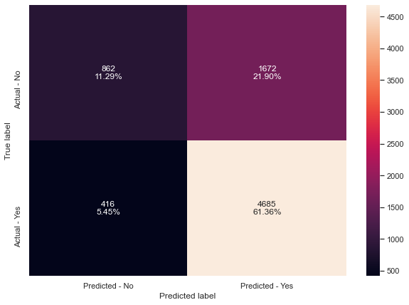

```python
make_confusion_matrix(gbc_tuned,y_test)
```

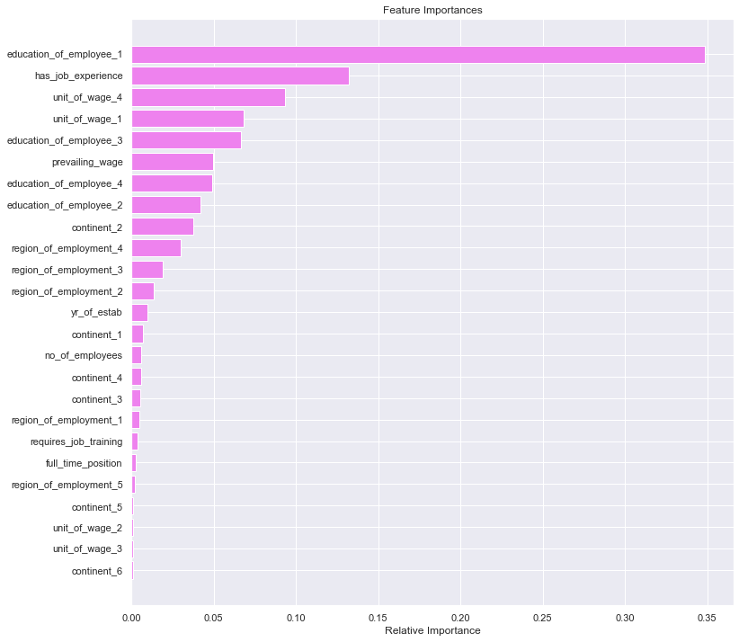

```python
importances = gbc_tuned.feature_importances_
indices = np.argsort(importances)
feature_names = list(X.columns)

plt.figure(figsize=(12,12))
plt.title('Feature Importances')
plt.barh(range(len(indices)), importances[indices], color='violet', align='center')
plt.yticks(range(len(indices)), [feature_names[i] for i in indices])
plt.xlabel('Relative Importance')
plt.show()
```

### XGBoost Classifier

```python
# Choose the type of classifier.
xgb_tuned = XGBClassifier(random_state=1,eval_metric='logloss')

# Grid of parameters to choose from
## add from
parameters = {
    "n_estimators": np.arange(10,100,20),
    "scale_pos_weight":[0,1,2,5],
    "subsample":[0.5,0.7,0.9,1],
    "learning_rate":[0.01,0.1,0.2,0.05],
    "gamma":[0,1,3],
    "colsample_bytree":[0.5,0.7,0.9,1],
    "colsample_bylevel":[0.5,0.7,0.9,1]
}

# Type of scoring used to compare parameter combinations
acc_scorer = metrics.make_scorer(metrics.recall_score)

# Run the grid search
grid_obj = GridSearchCV(xgb_tuned, parameters,scoring=acc_scorer,cv=5)
grid_obj = grid_obj.fit(X_train, y_train)

# Set the clf to the best combination of parameters
xgb_tuned = grid_obj.best_estimator_

# Fit the best algorithm to the data.
xgb_tuned.fit(X_train, y_train)
```

```
XGBClassifier(base_score=0.5, booster='gbtree', callbacks=None,
              colsample_bylevel=0.5, colsample_bynode=1, colsample_bytree=0.5,
              early_stopping_rounds=None, enable_categorical=False,
              eval_metric='logloss', gamma=0, gpu_id=-1,
              grow_policy='depthwise', importance_type=None,
              interaction_constraints='', learning_rate=0.01, max_bin=256,
              max_cat_to_onehot=4, max_delta_step=0, max_depth=6, max_leaves=0,
              min_child_weight=1, missing=nan, monotone_constraints='()',
              n_estimators=30, n_jobs=0, num_parallel_tree=1, predictor='auto',
              random_state=1, reg_alpha=0, reg_lambda=1, ...)
```

```python
#Using above defined function to get accuracy, recall and precision on train and test set
xgb_tuned_score=get_metrics_score(xgb_tuned)
```

```
Accuracy on training set :  0.6682012126656187
Accuracy on test set :  0.6681074001309758
Recall on training set :  1.0
Recall on test set :  1.0
Precision on training set :  0.6681639528354857
Precision on test set :  0.6681074001309758
```

```python
make_confusion_matrix(xgb_tuned,y_test)
```

[output not shown]

Great fit on this model. The test and training set are matching very closely.

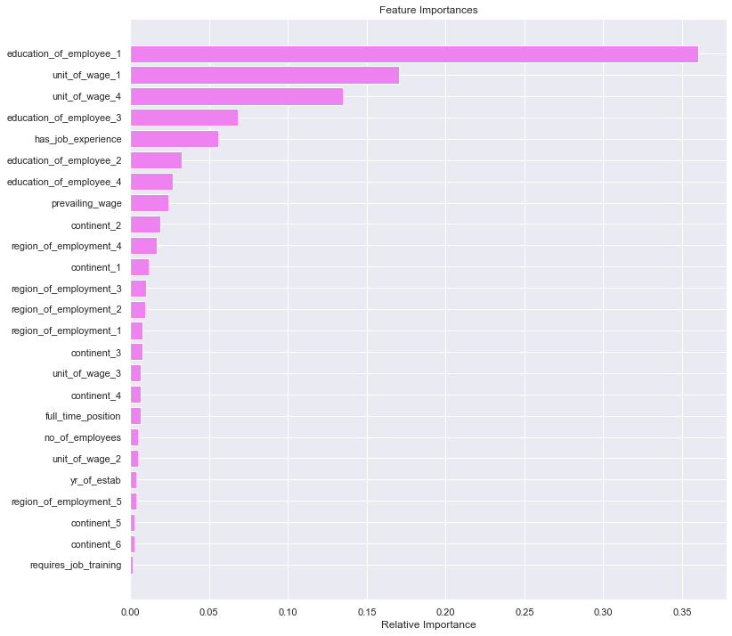

```python
importances = xgb_tuned.feature_importances_
indices = np.argsort(importances)
feature_names = list(X.columns)

plt.figure(figsize=(12,12))
plt.title('Feature Importances')
plt.barh(range(len(indices)), importances[indices], color='violet', align='center')
plt.yticks(range(len(indices)), [feature_names[i] for i in indices])
plt.xlabel('Relative Importance')
plt.show()
```

Education, wage and job experience also top the list of most important features.

## Model Performance Comparison and Conclusions

```python
# defining list of models
models = [bagging_estimator,bagging_estimator_tuned,bagging_lr, rf_estimator, rf_estimator_tuned,
          abc, abc_tuned, gbc, gbc_init, gbc_tuned, xgb, xgb_tuned]

# defining empty lists to add train and test results
acc_train = []
acc_test = []
recall_train = []
recall_test = []
precision_train = []
precision_test = []

# looping through all the models to get the accuracy, precall and precision scores
for model in models:
    j = get_metrics_score(model,False)
    acc_train.append(np.round(j[0],2))
    acc_test.append(np.round(j[1],2))
    recall_train.append(np.round(j[2],2))
    recall_test.append(np.round(j[3],2))
    precision_train.append(np.round(j[4],2))
    precision_test.append(np.round(j[5],2))
```

```python
comparison_frame = pd.DataFrame({'Model':['Bagging classifier with default parameters','Tuned Bagging Classifier',
                                          'Bagging classifier with base_estimator=LR',
                                          'Random Forest with default parameters',
                                          'Tuned Random Forest Classifier','AdaBoost with default paramters',
                                          'AdaBoost Tuned', 'Gradient Boosting with default parameters',
                                          'Gradient Boosting with init=AdaBoost', 'Gradient Boosting Tuned',
                                          'XGBoost with default parameters','XGBoost Tuned'],
                                          'Train_Accuracy': acc_train,'Test_Accuracy': acc_test,
                                          'Train_Recall':recall_train,'Test_Recall':recall_test,
                                          'Train_Precision':precision_train,'Test_Precision':precision_test})
comparison_frame
```

|  | Model | Train_Accuracy | Test_Accuracy | Train_Recall | Test_Recall | Train_Precision | Test_Precision |
| --- | --- | --- | --- | --- | --- | --- | --- |
| 0 | Bagging classifier with default parameters | 0.99 | 0.70 | 0.99 | 0.78 | 0.99 | 0.77 |
| 1 | Tuned Bagging Classifier | 0.67 | 0.67 | 1.00 | 1.00 | 0.67 | 0.67 |
| 2 | Bagging classifier with base_estimator=LR | 0.67 | 0.67 | 1.00 | 1.00 | 0.67 | 0.67 |
| 3 | Random Forest with default parameters | 1.00 | 0.72 | 1.00 | 0.83 | 1.00 | 0.77 |
| 4 | Tuned Random Forest Classifier | 0.76 | 0.75 | 0.88 | 0.87 | 0.79 | 0.78 |
| 5 | AdaBoost with default paramters | 0.74 | 0.73 | 0.89 | 0.88 | 0.76 | 0.76 |
| 6 | AdaBoost Tuned | 0.69 | 0.69 | 0.97 | 0.97 | 0.69 | 0.69 |
| 7 | Gradient Boosting with default parameters | 0.76 | 0.75 | 0.88 | 0.87 | 0.78 | 0.78 |
| 8 | Gradient Boosting with init=AdaBoost | 0.76 | 0.75 | 0.88 | 0.87 | 0.78 | 0.78 |
| 9 | Gradient Boosting Tuned | 0.73 | 0.73 | 0.92 | 0.92 | 0.74 | 0.74 |
| 10 | XGBoost with default parameters | 0.83 | 0.74 | 0.93 | 0.86 | 0.84 | 0.77 |
| 11 | XGBoost Tuned | 0.67 | 0.67 | 1.00 | 1.00 | 0.67 | 0.67 |

## Actionable Insights and Recommendations

All the models agreed that the most important feature for modeling is a high school education.